# Storm Data Analysis - Peer Assessment 2

July 25, 2014

## Synopsis

This data analysis uses the U.S. National Oceanic and Atmospheric Administration’s (NOAA) storm database to address the following questions:

1. Across the United States, which types of events (as indicated in the EVTYPE variable) are most harmful with respect to population health?
2. Across the United States, which types of events have the greatest economic consequences?

The purpose of this analysis is to review historical severe weather events in order to prioritize resources for future contingencies.

## Data Processing

### Download storm data, documentation and FAQ

Set working directory:

```r
setwd("~/GitHub/RepData_PeerAssessment2")
```

Create a data subdirectory if it does not exist:

```r
if (!file.exists("data")) {
        dir.create("data")
}
```

Download *Storm Data* and unzip if it isn’t already there:

```r
library(R.utils, quietly = TRUE)                        #for bzunzip
```

```r
fileDir <- "./data/"
fileZipName <- "repdata-data-StormData.csv.bz2"
fileName <- "repdata-data-StormData.csv"
fileUrl <- "https://d396qusza40orc.cloudfront.net/repdata%2Fdata%2FStormData.csv.bz2"

filePath <- paste0(fileDir, fileZipName)
if (!file.exists(filePath)) {
        download.file(fileUrl, destfile = filePath, method ="curl")
        bunzip2(filePath, exdir=fileDir, remove=FALSE)
        dateDownloaded <- date()
}
```

Download documentation files: *National Weather Service Storm Data Documentation* and *National Climatic Data Center Storm Events FAQ*

```r
fileName2 <- "repdata-peer2_doc-pd01016005curr.pdf"
fileUrl2 <- "https://d396qusza40orc.cloudfront.net/repdata%2Fpeer2_doc%2Fpd01016005curr.pdf"
filePath2 <- paste0(fileDir, fileName2)
if (!file.exists(filePath2)) {
        download.file(fileUrl2, destfile = filePath2, method ="curl")
        dateDownloaded <- date()
}

fileName3 <- "repdata-peer2_doc-NCDC Storm Events-FAQ Page.pdf"
fileUrl3 <- "https://d396qusza40orc.cloudfront.net/repdata%2Fpeer2_doc%2FNCDC%20Storm%20Events-FAQ%20Page.pdf"
filePath3 <- paste0(fileDir, fileName3)
if (!file.exists(filePath3)) {
        download.file(fileUrl3, destfile = filePath3, method ="curl")
        dateDownloaded <- date()
}
```

### Read in data file, subset and clean

```r
raw <- read.csv(paste0(fileDir, fileName))
data <- subset(raw, na.omit=TRUE, select=c(EVTYPE, FATALITIES, INJURIES, PROPDMG, PROPDMGEXP))
```

### Run analysis

Compute property damage cost by multiplying damage variable *PROPDMG* by the exponent variable *PROPDMGEXP*

```r
cost <- rep(NA, nrow(data))                                                     # damage cost
for (i in 1:nrow(data)) {
        if (sum(data[i,"PROPDMGEXP"] == c(0:9)) != 0) {                         # exponent 0-9
                cost[i] <- data[i,"PROPDMG"] *
                        10^as.integer(as.character(data[i,"PROPDMGEXP"]))
        }
        else if (sum(data[i,"PROPDMGEXP"] == c("b","B")) != 0) {                # billions
                cost[i] <- data[i,"PROPDMG"] * 10^9
        }
        else if (sum(data[i,"PROPDMGEXP"] == c("m","M")) != 0) {                # millions
                cost[i] <- data[i,"PROPDMG"] * 10^6
        }
        else if (sum(data[i,"PROPDMGEXP"] == c("h","H","k","K")) != 0) {        # thousands
                cost[i] <- data[i,"PROPDMG"] * 10^3
        }
        else {
                cost[i] <- data[i,"PROPDMG"]
        }
}
data <- cbind(data,cost)
```

Determine total injuries, deaths and property damage costs by weather event type:

```r
toplevels <- 20
unsorted_injured_by_event <- tapply(data$INJURIES, data$EVTYPE,
                           sum, simplify = TRUE)                # simply returns a scalar not list
injured_by_event <- sort(unsorted_injured_by_event, decreasing = TRUE)
top_injury_events <- head(injured_by_event, n=toplevels)
top_injury_events <- sort(top_injury_events, decreasing = FALSE)        # reverse sort order

unsorted_deaths_by_event <- tapply(data$FATALITIES, data$EVTYPE, sum, simplify = TRUE)
deaths_by_event <- sort(unsorted_deaths_by_event, decreasing = TRUE)
top_death_events <- head(deaths_by_event, n=toplevels)
top_death_events <- sort(top_death_events, decreasing = FALSE)

unsorted_cost_by_event <- tapply(data$cost, data$EVTYPE, sum, simplify = TRUE)
cost_by_event <- sort(unsorted_cost_by_event, decreasing = TRUE)
top_cost_events <- head(cost_by_event, n=toplevels)
top_cost_events <- sort(top_cost_events, decreasing = FALSE)
```

Tabulate the results for deaths, injuries and damage costs:

```r
combo <- cbind(unsorted_deaths_by_event, unsorted_injured_by_event,
               as.integer(unsorted_cost_by_event/10^6))
results <- combo[order(-unsorted_deaths_by_event),]
colnames(results) <- c("Deaths","Injuries","Damage($M)")
print(head(results, n=toplevels))
```

```
##                         Deaths Injuries Damage($M)
## TORNADO                   5633    91346      56947
## EXCESSIVE HEAT            1903     6525          7
## FLASH FLOOD                978     1777      16822
## HEAT                       937     2100          1
## LIGHTNING                  816     5230        930
## TSTM WIND                  504     6957       4484
## FLOOD                      470     6789     144657
## RIP CURRENT                368      232          0
## HIGH WIND                  248     1137       5270
## AVALANCHE                  224      170          3
## WINTER STORM               206     1321       6688
## RIP CURRENTS               204      297          0
## HEAT WAVE                  172      309         10
## EXTREME COLD               160      231         67
## THUNDERSTORM WIND          133     1488       3483
## HEAVY SNOW                 127     1021        932
## EXTREME COLD/WIND CHILL    125       24          8
## STRONG WIND                103      280        175
## BLIZZARD                   101      805        659
## HIGH SURF                  101      152         89
```

## Results

With respect to analyzing the question *which types of events (as indicated in the EVTYPE variable) are most harmful with respect to population health?*, the plots in Figures 1 & 2 are illustrative.

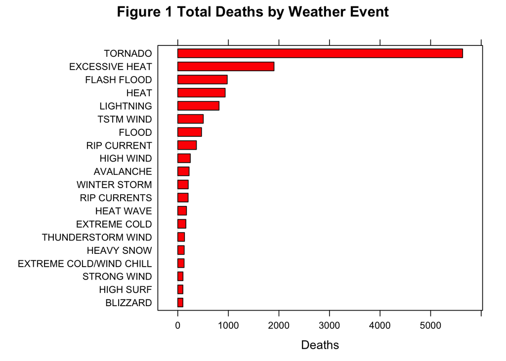

```r
library(lattice)
barchart(top_death_events, col="red", xlab='Deaths', main='Figure 1 Total Deaths by Weather Event')
```

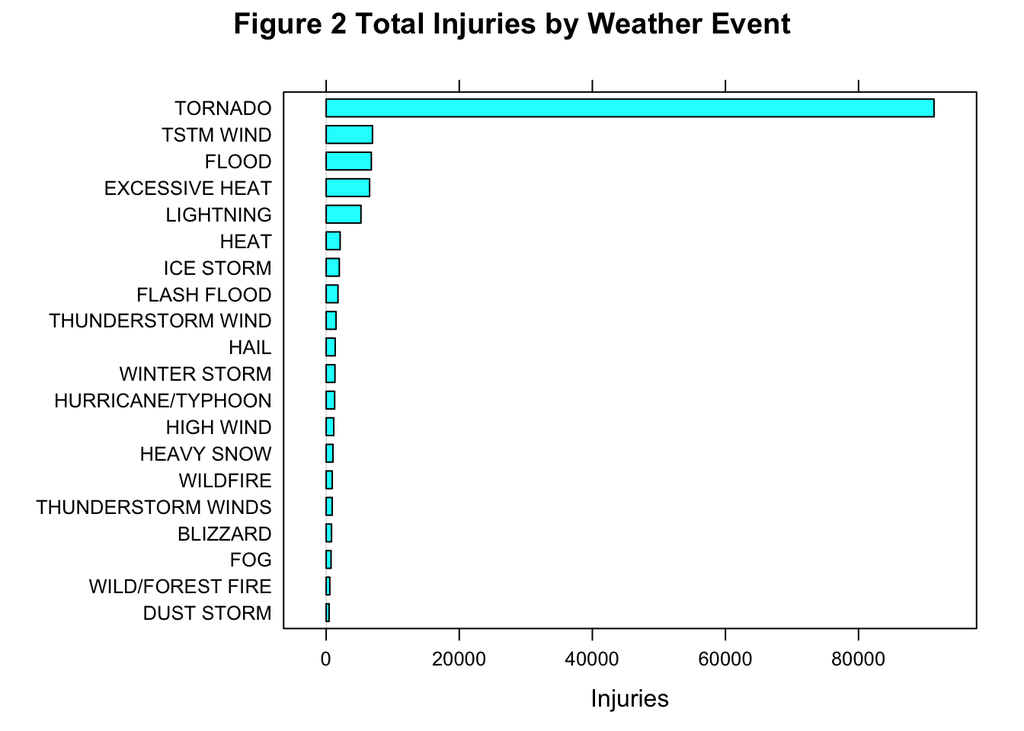

```r
barchart(top_injury_events, xlab='Injuries', main='Figure 2 Total Injuries by Weather Event')
```

In terms of studying the question *which types of events have the greatest economic consequences?* the following plot is informative.

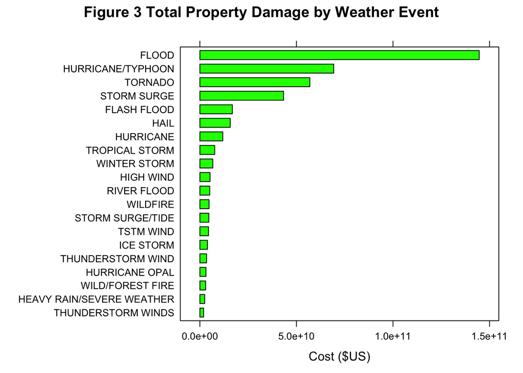

```r
barchart(top_cost_events, col="green", xlab='Cost ($US)',
         main='Figure 3 Total Property Damage by Weather Event')
```